# RMDay1

Rakyan Satrya Adhikara

5/8/2019

# Regression Model

Ex/ Predicting the price of a house with only a ‘house price’ variable, the best approaching that can be used is with the value of mean.

## Simple Linear Regression

```
## 'data.frame':    62 obs. of  15 variables:
##  $ Row.ID      : int  336 393 407 516 596 754 1151 1234 1550 1645 ...
##  $ Order.ID    : Factor w/ 62 levels "CA-2014-116666",..: 17 49 37 39 4 26 15 32 5 14 ...
##  $ Order.Date  : Factor w/ 61 levels "1/22/17","1/4/16",..: 53 58 21 1 52 34 33 37 47 25 ...
##  $ Ship.Date   : Factor w/ 59 levels "1/27/17","1/9/16",..: 57 56 15 1 48 32 31 37 45 25 ...
##  $ Ship.Mode   : Factor w/ 4 levels "First Class",..: 3 3 4 4 4 1 2 1 1 1 ...
##  $ Customer.ID : Factor w/ 59 levels "AB-10255","AD-10180",..: 14 36 41 2 43 59 46 6 25 27 ...
##  $ Segment     : Factor w/ 3 levels "Consumer","Corporate",..: 1 1 1 3 1 2 1 2 1 2 ...
##  $ Product.ID  : Factor w/ 12 levels "TEC-CO-10000971",..: 3 8 11 9 11 7 12 2 2 5 ...
##  $ Category    : Factor w/ 1 level "Technology": 1 1 1 1 1 1 1 1 1 1 ...
##  $ Sub.Category: Factor w/ 1 level "Copiers": 1 1 1 1 1 1 1 1 1 1 ...
##  $ Product.Name: Factor w/ 12 levels "Brother DCP1000 Digital 3 in 1 Multifunction Machine",..: 10 6 12 2 12 9 1 3 3 7 ...
##  $ Sales       : num  960 1800 1200 3000 1200 ...
##  $ Quantity    : int  2 3 3 5 3 3 2 2 1 7 ...
##  $ Discount    : num  0.2 0 0.2 0 0.2 0.2 0 0.4 0.2 0 ...
##  $ Profit      : num  336 702 435 1380 435 ...
```

Connection plot between Sales and profit to predict profit based on Sales:

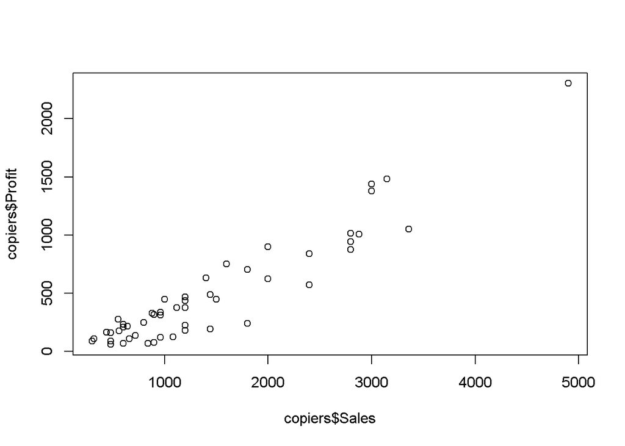

Checking outlier using ‘boxplot()’:

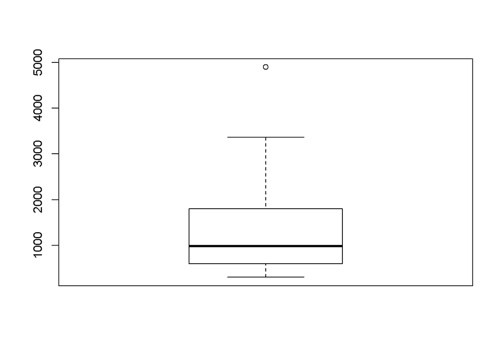

The corelation between ‘profit’ and ‘sales’ variables:

> Approaching 1: Good, strongly related

> Approaching -1: Bad, weakly related

```
## [1] 0.9395785
```

Making Linear Regression Model

```
##
## Call:
## lm(formula = Profit ~ Sales, data = copiers_clean)
##
## Residuals:
##     Min      1Q  Median      3Q     Max
## -386.43  -66.78   18.00   66.44  340.24
##
## Coefficients:
##              Estimate Std. Error t value Pr(>|t|)
## (Intercept) -83.54810   32.82978  -2.545   0.0136 *
## Sales         0.39444    0.02146  18.384   <2e-16 ***
## ---
## Signif. codes:  0 '***' 0.001 '**' 0.01 '*' 0.05 '.' 0.1 ' ' 1
##
## Residual standard error: 142.4 on 59 degrees of freedom
## Multiple R-squared:  0.8514, Adjusted R-squared:  0.8489
## F-statistic:   338 on 1 and 59 DF,  p-value: < 2.2e-16
```

### Formula dari model_rm:

Intercept = -83.54810 Slope = 0.39444

Profit = -83.54810 + 0.39444 * Sales

It means that every time sales went uo by 1, the profit will be up too with 0.39444

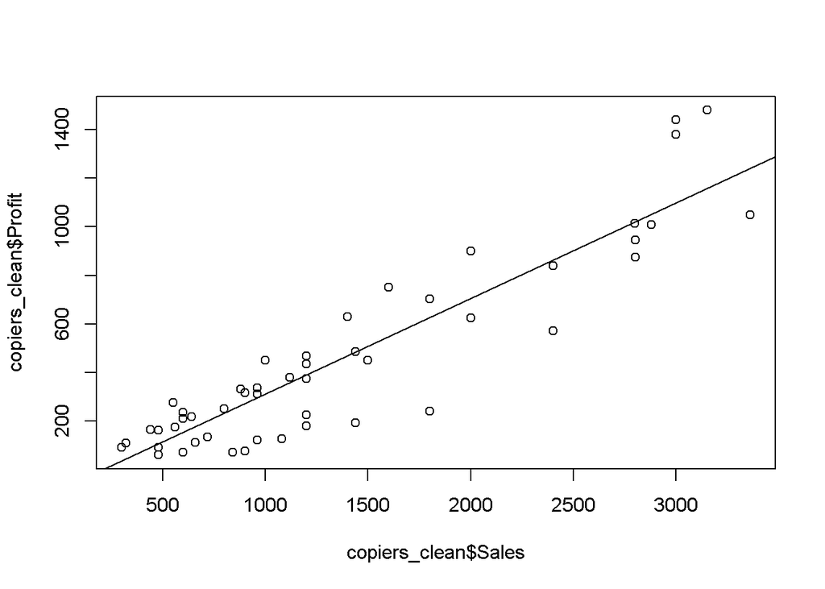

> P-Value on every coefficient will show significance level as a predictor. **The most recommended predictor** is the one with **at least 0.05 or at least on ’*’**

> the **R-Squared** range is in *between 0 and 1*. *The more it gets into 1, the more accurate the predictor can describe the target*. In this case, the R-Squared of ‘Sales’ is ~0.85. Thus, ‘Sales’ can describe 85% of the ‘Profit’

Exe/

- if ‘Sales’ is equal to 350, how much is the profit?

```
## [1] 54.5059
```

- if ‘Sales’ is equal to 245, how much is the profit?

```
## [1] 13.0897
```

- if ‘Sales’ is equal to 245, 370, 210 and 400, how much is the profir for every ‘Sales’?

```
## [1] 13.0897 62.3947 -0.7157 74.2279
```

### Predict

the ‘predict()’ function is used to predict the data. The parameter that are being used are the model and the data that are going to be predicted

```r
predict(object = model_rm, newdata = data.frame(Sales = c(245, 370, 210, 400)))
```

```
##          1          2          3          4
## 13.0886718 62.3931476 -0.7165815 74.2262218
```

### Error

#### MSE (**M**ean **S**quare **E**rror)

The **M**ean value of **S**quared **E**rrors

#### RMSE (**R**oot **M**ean **S**quare **E**rror)

The **R**ooted value of **MSE**

#### MAE (**M**ean **A**bsolute **E**rror)

The **M**ean Value of ‘**A**bsolute’ condition of the **E**rrors

#### RMSE v MAE

- 1. RMSE **!<** MAE
  2. RMSE can be used if the *‘extreme’* error are getting displayed since the characteristic of square is to make big values become bigger and small values become smaller
  3. MAE can be used if **not** the *‘extreme’* error are getting displayed.

# Terms that are being used in ‘Machine-Learning’:

- X1, X2, X3, … -> Predictors, Independent Variables
- Y -> Target, Dependent Variable
- Residual = Error -> ‘Expectation - Reality’
- R-Squared -> on what percentage the predictor can describe the target